# Traffic Accidents in Maryland

Alex Liu

## Introduction

Every year, millions of traffic accidents occur in the United States. In 2019, over thirty-three thousand of these were fatal resulting in over thirty-six thousand deaths, with millions more having serious injuries requiring hospitalization. Traffic-related deaths are the leading cause of death among non-senior Americans.

Measures such as traffic control, stricter or more widespread enforcement of traffic laws, and increased patrols can help lower the number of accidents, but are a strain on city budgets. It can therefore be useful to determine if there are times where it is better to deploy more resources and times where less resources can be used, in order to balance costs.

## Setup

The data that will be used is a public dataset released by the government of Maryland on accidents occuring on facilities owned by the Maryland Transportation Authority or accidents responded to by MDTA police. The date range of the accidents is July 2012 to November 2020, or a period of 101 months (this number will be used later). The dataset can be downloaded as a csv file here: https://opendata.maryland.gov/Public-Safety/MDTA-Accidents/rqid-652u. Place this in the same directory as this notebook.

Then, import the following libraries:

- Pandas: used for storing and manipulating the data through its dataframe feature
- Matplotlib: used for creating graphs and charts
- Scikit-learn: used for regression and machine learning
- Datetime: used for storing datetimes as objects
- Statsmodels: used for testing involving statistic models

```python
import pandas as pd
import matplotlib.pyplot as plt
from sklearn.linear_model import LinearRegression
from datetime import datetime
from statsmodels.stats import weightstats as stests
```

Import the data into a pandas dataframe and preview it:

```python
df = pd.read_csv("MDTA_Accidents.csv")
df.head()
```

|  | CC Number | Date | Time | Accident Type | New Georeferenced Column |
| --- | --- | --- | --- | --- | --- |
| 0 | 19CS00072041 | 04/12/2019 | 4/12/2019 7:45:00 PM | Injury Crash | (38.98807, -76.35499) |
| 1 | 19CS00082980 | 04/28/2019 | 4/29/2019 1:46:00 AM | Injury Crash | (39.244952, -76.577341) |
| 2 | 20CS00118175 | 07/16/2020 | 7/18/2020 5:35:00 AM | Property Damage Crash | (39.07619522, -76.90696919) |
| 3 | 20CS00116936 | 07/14/2020 | 7/17/2020 11:10:00 PM | Property Damage Crash | (39.08727726, -76.97976361) |
| 4 | 20CS00115004 | 07/11/2020 | 7/11/2020 1:18:00 AM | Property Damage Crash | (39.2802, -76.5534) |

## Cleaning up the data

A look through the entire dataset shows inconsistency between dates in the Date and Time columns, and furthermore inconsistent formatting across entries in the Time column. This will need to be standardized to allow for easier analysis later on. The Time column has several different formats, which along with the Date column will be converted into a new DateTime column as follows:

1. `M/D/YYYY H:MM:SS AM/PM` - no change
2. `H:MM:SS AM/PM` - time will be combined with the Date column
3. `HHMM or HMM` - time will be combined with the Date column
4. `YYYY-MM-DDTHH:MM:SS.000` - time will be combined with the Date column
5. `M/D/YYYY` - time will be set to midnight

The Accident Type column also has inconsistent formatting with some rows using the full phrase and some rows using abbreviations. Phrases will be converted to abbreviations as follows:

1. `Property Damage Crash, pd` - PD
2. `Injury Crash` - PI
3. `Fatal Crash` - F

There is one row with Accident Type "IS"; as its meaning is not readily apparent it will be ignored.

```python
datetimes = []

for i, row in df.iterrows():
    # standardize datetimes
    date = row['Date']
    time = row['Time'].split()
    try:
        if 'T' in row['Time']: # YYYY-MM-DDTHH:MM:SS.000
            time = row['Time'].split('T')[1]
            time = time.split('.')[0]
            datetimes.append(datetime.strptime(date + ' ' + time, '%m/%d/%Y %H:%M:%S'))
        elif len(time) == 3: # M/D/YYYY H:MM:SS AM/PM
            datetimes.append(datetime.strptime(row['Time'], '%m/%d/%Y %I:%M:%S %p'))
        elif len(time) == 2: # H:MM:SS AM/PM
            datetimes.append(datetime.strptime(date + ' ' + row['Time'], '%m/%d/%Y %I:%M:%S %p'))
        elif len(time) == 1: # HHMM or HMM
            hour = row['Time'][:1] if len(row['Time']) == 3 else row['Time'][:2]
            minute = row['Time'][-2:]
            datetimes.append(datetime.strptime(date + ' ' + hour + ':' + minute, '%m/%d/%Y %H:%M'))
    except: # M/D/YYYY
        datetimes.append(datetime.strptime(row['Time'], '%m/%d/%Y'))

    # standardize accident types
    if row['Accident Type'] == 'Property Damage Crash' or row['Accident Type'] == 'pd':
        row['Accident Type'] = 'PD'
    elif row['Accident Type'] == 'Injury Crash':
        row['Accident Type'] = 'PI'
    elif row['Accident Type'] == 'Fatal Crash':
        row['Accident Type'] = 'F'
    elif row['Accident Type'] == 'IS':
        row['Accident Type'] = None

# insert new Datetime column and remove Date and Time columns
df.insert(len(df.columns), "Datetime", datetimes, True)
df = df.drop(columns=['Date', 'Time'])
```

Ignored cells were set to None to flag the row for deletion, which can be done as follows:

```python
df = df.dropna(axis=0, subset=['Accident Type'])
```

The "CC Number" and "New Georeferenced Column" columns will not be too useful for analysis and so will be dropped:

```python
df = df.drop(columns=['CC Number','New Georeferenced Column'])
```

The new dataframe, now cleaned up, will look like this:

```python
df.head()
```

|  | Accident Type | Datetime |
| --- | --- | --- |
| 0 | PI | 2019-04-12 19:45:00 |
| 1 | PI | 2019-04-29 01:46:00 |
| 2 | PD | 2020-07-18 05:35:00 |
| 3 | PD | 2020-07-17 23:10:00 |
| 4 | PD | 2020-07-11 01:18:00 |

## Data Representation

Creating some simple graphs can be useful for finding potential trends in the data that may be worth looking into, as it is easier when the data are represented visually. One likely trend would be the number of accidents compared to some measure of time.

As there is a relatively low number of accidents on any given day, a graph based on this measure would be largely useless. It is better to instead sum up the number of accidents in each month for each year. Create a simple graph of the number of accidents over time, grouped by month:

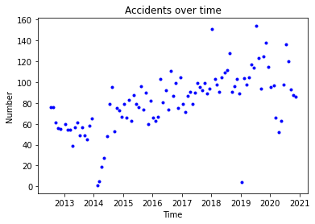

```python
# add up the number of accidents for each unique month
data = {}
for i, row in df.iterrows():
    # create datetime containing only month and year with arbitrary standardized day for plotting purposes
    dt = datetime(month=row['Datetime'].month, year=row['Datetime'].year, day=15)
    data[dt] = data[dt] + 1 if dt in data else 1

# plot data
plt.scatter(data.keys(), data.values(), c="b", marker='.')
plt.xlabel("Time")
plt.ylabel("Number")
plt.title('Accidents over time')
plt.show()
```

It appears that the number of accidents each month is steadily increasing over the past 8 years. It may be more useful to see how the number changes over time by month. These will need to be weighted by year given that the number of accidents increases each year.

Create a graph of the number of accidents in each month:

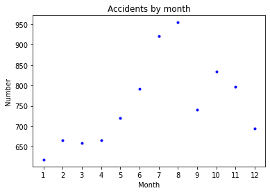

```python
# get the total number of accidents in each year
year_accidents = {}
for i, row in df.iterrows():
    year = row['Datetime'].year
    year_accidents[year] = year_accidents[year] + 1 if year in year_accidents else 1

mean = sum(year_accidents.values()) / len(year_accidents.values())

# weight the data and group by month
data = {}
for i, row in df.iterrows():
    month = row['Datetime'].month
    year = row['Datetime'].year
    data[month] = data[month] + year_accidents[year] / mean if month in data else year_accidents[year] / mean

# create scatterplot
plt.scatter(data.keys(), data.values(), c="b", marker='.')
plt.xlabel("Month")
plt.ylabel("Number")
plt.xticks(range(1,13))
plt.title('Accidents by month')
plt.show()
```

The new graph now gives significantly more insight into the data. It indicates that in total, the number of accidents is at the highest in August, is relatively high for the surrounding few months, and is at the lowest in January. However, while visually there appears to be significant variation between the months, in particular between August and January, the y-axis does not start at zero and so the scaling is misleading. A better visualization for this would be a pie chart. Create one as follows:

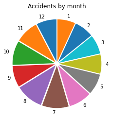

```python
# create list of month numbers and reverse for display purposes
labels = list(range(1,13))[::-1]
# get the data for each month in properly sorted order (reversed due to previous line)
sizes = [data[x] for x in sorted(data.keys(), reverse=True)]
# create and format pie chart
plt.pie(sizes, labels=labels, explode=[0.05]*12, startangle=90)
plt.title('Accidents by month')
plt.show()
```

The number of accidents in each month now appear much closer to each other when treated as percentages, and thus it is not readily obvious if there is a correlation between month and number of accidents. One way to figure out if there may actually be a correlation is covered in the next section.

Another variable that can be looked at is the type of accident. The accidents are again graphed over time and grouped by month but are now separated into the three given accident types.

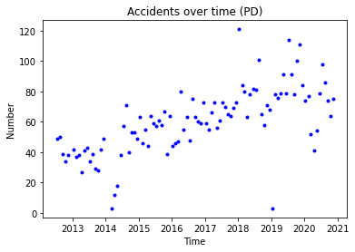

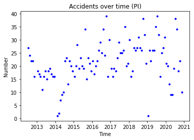

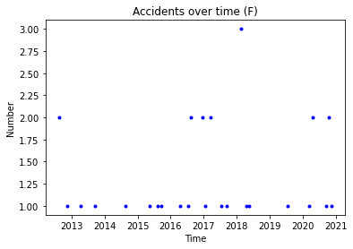

```python
# create dataframes filtered by accident type
df_pd = df[(df['Accident Type'] == 'PD')]
df_pi = df[(df['Accident Type'] == 'PI')]
df_f = df[(df['Accident Type'] == 'F')]

for name,df1 in {'PD':df_pd, 'PI':df_pi, 'F':df_f}.items():
    data = {}
    for i, row in df1.iterrows():
        # create datetime containing only month and year with arbitrary standardized day for plotting purposes
        dt = datetime(month=row['Datetime'].month, year=row['Datetime'].year, day=15)
        data[dt] = data[dt] + 1 if dt in data else 1

    # plot data
    plt.scatter(data.keys(), data.values(), c="b", marker='.')
    plt.xlabel("Time")
    plt.ylabel("Number")
    plt.title('Accidents over time (' + name + ')')
    plt.show()
```

Property damage crashes continue to display a steady increase in number over time while injury crashes have much greater variation. There are too few data points for fatal crashes to make any reasonable observations or continue with further analysis. A quick count of the number of data points for each accident type can be done as follows, and confirms this:

```python
df1 = df.groupby('Accident Type', as_index=False).agg(['count'])
df1.columns = ['Count']
df1
```

| Accident Type | Count |
| --- | --- |
| F | 33 |
| PD | 5937 |
| PI | 2129 |

The accidents are also again graphed over time by month and plotted in a pie chart but separated into the three given accident types:

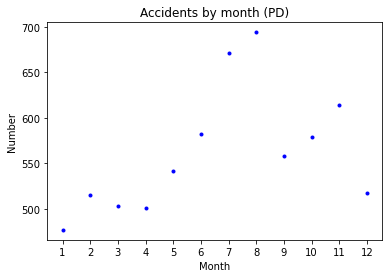

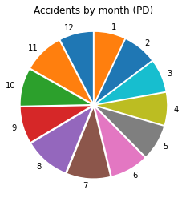

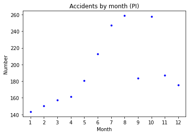

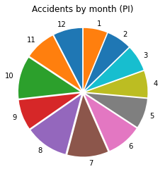

```python
for name,df1 in {'PD':df_pd, 'PI':df_pi}.items():
    # get the total number of accidents in each year
    year_accidents = {}
    for i, row in df1.iterrows():
        year = row['Datetime'].year
        year_accidents[year] = year_accidents[year] + 1 if year in year_accidents else 1

    mean = sum(year_accidents.values()) / len(year_accidents.values())

    # weight the data and group by month
    data = {}
    for i, row in df1.iterrows():
        month = row['Datetime'].month
        year = row['Datetime'].year
        data[month] = data[month] + year_accidents[year] / mean if month in data else year_accidents[year] / mean

    # create scatterplot
    plt.scatter(data.keys(), data.values(), c="b", marker='.')
    plt.xlabel("Month")
    plt.ylabel("Number")
    plt.xticks(range(1,13))
    plt.title('Accidents by month (' + name + ')')
    plt.show()

    # create list of month numbers and reverse for display purposes
    labels = list(range(1,13))[::-1]
    # get the data for each month in properly sorted order (reversed due to previous line)
    sizes = [data[x] for x in sorted(data.keys(), reverse=True)]
    # create and format pie chart
    plt.pie(sizes, labels=labels, explode=[0.05]*12, startangle=90)
    plt.title('Accidents by month (' + name + ')')
    plt.show()
```

This does not give appear to give any new insights, as the graphs for each type still look roughly similar to the original combined graph, and the pie charts still do not indicate significant differences in number of accidents across months.

## Hypothesis Testing

Hypothesis testing uses statistics to test whether some claim made about the data is true or not. There are several components to hypothesis testing. The **null hypothesis** (H<sub>0</sub>) is the claim to be tested and potentially rejected, while the **alternate hypothesis** (H<sub>a</sub>) is the claim to be accepted if the null hypothesis is rejected. The **significance level** (α), a number between 0 and 1 and usually small, is used to determine when the null hypothesis should be rejected. This occurs when the p-value returned by the test is less than the significance level.

In this example:

- H<sub>0</sub>: August does not have a significantly higher number of crashes (or is not significantly different from mean)
- H<sub>a</sub>: August does have a significantly higher number of crashes (or is significantly different from mean)
- α: 0.05

As equality is being tested, a two-tailed test is used. A one-tailed test would be used if an inequality was being tested.

```python
# sum the number of accidents in each month for each year
years = {}
for i, row in df.iterrows():
    if row['Datetime'].month == 8:
        year = row['Datetime'].year
        years[year] = years[year]+1 if year in years else 1

mean = len(df) / 101
ztest,pval = stests.ztest(list(years.values()), value=mean, alternative='two-sided')
print(pval)
```

```
0.010152453316452831
```

As the p-value of 0.01 is less than the significant level of 0.05, the null hypothesis can be rejected in favor of the alternative hypothesis, in that August has a significantly higher number of crashes.

## Machine Learning

Machine learning uses an existing dataset to train a model that can then be used to predict values out of the dataset's range. One of the simpler methods uses linear regression, which will be used for the model here. This example will use variables for both month and year. These are termed interaction variables as they all have some effect on the number of crashes. One will be created for the year and one each will be created for the months.

The dataframe is first grouped by month and year, and preprocessed into the two input arrays for the model:

```python
# group by month and year
monthyears = {}
for i,row in df.iterrows():
    monthyear = str(row['Datetime'].month) + str(row['Datetime'].year)
    monthyears[monthyear] = monthyears[monthyear] + 1 if monthyear in monthyears else 1

# create input arrays
x = []
y = []

# set the interaction variables
for monthyear,count in monthyears.items():
    year = int(monthyear[-4:])
    month = int(monthyear[:1]) if len(monthyear) == 5 else int(monthyear[:2])
    months = [0] * 12
    months[month-1] = year
    x.append([year] + months)
    y.append(count)

# create model
reg = LinearRegression().fit(x,y)
print("Coefficients:")
print(reg.coef_)
print("Intercept")
print(reg.intercept_)
```

```
Coefficients:
[6.85468576 0.56650793 0.56465507 0.56458815 0.56489777 0.56824435
 0.57283359 0.57895861 0.58148827 0.57007732 0.57443306 0.57244987
 0.57555176]
Intercept
-14891.216128577671
```

To use the model at year y and month number m, multiply y to the coefficients at both element 0 (the year) and element m (the month) and add both to the intercept.

Some examples:

```python
print("January 2013:")
print(round(reg.intercept_ + reg.coef_.tolist()[0]*2013 + reg.coef_.tolist()[1]*2013,2))
print("January 2020:")
print(round(reg.intercept_ + reg.coef_.tolist()[0]*2020 + reg.coef_.tolist()[1]*2020,2))
print("August 2013:")
print(round(reg.intercept_ + reg.coef_.tolist()[0]*2013 + reg.coef_.tolist()[8]*2013,2))
print("August 2020:")
print(round(reg.intercept_ + reg.coef_.tolist()[0]*2020 + reg.coef_.tolist()[8]*2020,2))
```

```
January 2013:
47.65
January 2020:
99.6
August 2013:
77.8
August 2020:
129.86
```

To get a sense of how accurate this model is, calculate the residuals (actual value - predicted value) and graph them:

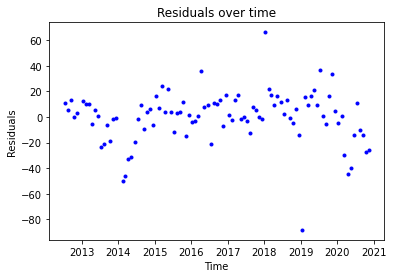

```python
# get residuals for each month and year
residuals = {}
for monthyear,count in monthyears.items():
    year = int(monthyear[-4:])
    month = int(monthyear[:1]) if len(monthyear) == 5 else int(monthyear[:2])
    predicted = reg.intercept_ + reg.coef_.tolist()[0]*year + reg.coef_.tolist()[month]*year
    residuals[datetime(year=year, month=month, day=15)] = count - predicted

# create scatter plot
plt.scatter(residuals.keys(), residuals.values(), c="b", marker='.')
plt.xlabel("Time")
plt.ylabel("Residuals")
plt.title('Residuals over time')
plt.show()
```

The majority of the residuals appear to be clustered around 0, indicating somewhat decent accuracy. A better measure of accuracy would be R<sup>2</sup>, which indicates how close the data are to the model. It can be calculated using the regression and data from earlier:

```python
reg.score(x,y)
```

```
0.5092617230223839
```

As R<sup>2</sup> is right in the middle at 0.51, the accuracy of the model is only about average.

## Conclusion

This tutorial has given an introduction to the data science pipeline and an example of how it can be applied in the real world. While analysis of the data was kept fairly brief, the results do seem to indicate that there is a correlation between month and number of accidents, with hypothesis testing conducted on the month of August indicating that the number of crashes during the month is significantly different than the overall average number of crashes. This information can serve as a motivator for the government to conduct additional in-depth analysis to reveal the full extent of this relationship, as it can assist them in better allocation of resources towards lowering the number of traffic accidents.

The use of machine learning can additionally assist the government in more accurate projections of the number of crashes by month and year for the future. While the model used in this example was not too accurate, the consideration of additional factors not found in the dataset such as time of day, weather, and amount of traffic can help improve these analyses and models.